# MiniProject

2023-12-02

## Given Information:

Dataset Source : https://archive.ics.uci.edu/ml/datasets/Bias+correction+of+numerical+ prediction+model+temperature+forecast

Target Variable to Predict : Next_Tmax

#### **(a) Preprocessing**

Summary of the dataset is as follows:

```r
library(readr)
data <- read_csv("Bias_correction_ucl.csv")
summary(data)
```

```
##     station        Date             Present_Tmax    Present_Tmin
##  Min.   : 1   Min.   :2013-06-30   Min.   :20.00   Min.   :11.30
##  1st Qu.: 7   1st Qu.:2014-07-15   1st Qu.:27.80   1st Qu.:21.70
##  Median :13   Median :2015-07-30   Median :29.90   Median :23.40
##  Mean   :13   Mean   :2015-07-30   Mean   :29.77   Mean   :23.23
##  3rd Qu.:19   3rd Qu.:2016-08-15   3rd Qu.:32.00   3rd Qu.:24.90
##  Max.   :25   Max.   :2017-08-30   Max.   :37.60   Max.   :29.90
##  NA's   :2    NA's   :2            NA's   :70      NA's   :70
##   LDAPS_RHmin     LDAPS_RHmax     LDAPS_Tmax_lapse LDAPS_Tmin_lapse
##  Min.   :19.79   Min.   : 58.94   Min.   :17.62    Min.   :14.27
##  1st Qu.:45.96   1st Qu.: 84.22   1st Qu.:27.67    1st Qu.:22.09
##  Median :55.04   Median : 89.79   Median :29.70    Median :23.76
##  Mean   :56.76   Mean   : 88.37   Mean   :29.61    Mean   :23.51
##  3rd Qu.:67.19   3rd Qu.: 93.74   3rd Qu.:31.71    3rd Qu.:25.15
##  Max.   :98.52   Max.   :100.00   Max.   :38.54    Max.   :29.62
##  NA's   :75      NA's   :75       NA's   :75       NA's   :75
##     LDAPS_WS         LDAPS_LH        LDAPS_CC1        LDAPS_CC2
##  Min.   : 2.883   Min.   :-13.60   Min.   :0.0000   Min.   :0.0000
##  1st Qu.: 5.679   1st Qu.: 37.27   1st Qu.:0.1467   1st Qu.:0.1406
##  Median : 6.547   Median : 56.87   Median :0.3157   Median :0.3124
##  Mean   : 7.098   Mean   : 62.51   Mean   :0.3688   Mean   :0.3561
##  3rd Qu.: 8.032   3rd Qu.: 84.22   3rd Qu.:0.5755   3rd Qu.:0.5587
##  Max.   :21.858   Max.   :213.41   Max.   :0.9673   Max.   :0.9684
##  NA's   :75       NA's   :75       NA's   :75       NA's   :75
##    LDAPS_CC3        LDAPS_CC4         LDAPS_PPT1         LDAPS_PPT2
##  Min.   :0.0000   Min.   :0.00000   Min.   : 0.00000   Min.   : 0.00000
##  1st Qu.:0.1014   1st Qu.:0.08153   1st Qu.: 0.00000   1st Qu.: 0.00000
##  Median :0.2626   Median :0.22766   Median : 0.00000   Median : 0.00000
##  Mean   :0.3184   Mean   :0.29919   Mean   : 0.59199   Mean   : 0.48500
##  3rd Qu.:0.4967   3rd Qu.:0.49949   3rd Qu.: 0.05252   3rd Qu.: 0.01836
##  Max.   :0.9838   Max.   :0.97471   Max.   :23.70154   Max.   :21.62166
##  NA's   :75       NA's   :75        NA's   :75         NA's   :75
##    LDAPS_PPT3        LDAPS_PPT4            lat             lon
##  Min.   : 0.0000   Min.   : 0.00000   Min.   :37.46   Min.   :126.8
##  1st Qu.: 0.0000   1st Qu.: 0.00000   1st Qu.:37.51   1st Qu.:126.9
##  Median : 0.0000   Median : 0.00000   Median :37.55   Median :127.0
##  Mean   : 0.2782   Mean   : 0.26941   Mean   :37.54   Mean   :127.0
##  3rd Qu.: 0.0079   3rd Qu.: 0.00004   3rd Qu.:37.58   3rd Qu.:127.0
##  Max.   :15.8412   Max.   :16.65547   Max.   :37.65   Max.   :127.1
##  NA's   :75        NA's   :75
##       DEM             Slope         Solar radiation   Next_Tmax
##  Min.   : 12.37   Min.   :0.09847   Min.   :4330    Min.   :17.40
##  1st Qu.: 28.70   1st Qu.:0.27130   1st Qu.:4999    1st Qu.:28.20
##  Median : 45.72   Median :0.61800   Median :5436    Median :30.50
##  Mean   : 61.87   Mean   :1.25705   Mean   :5342    Mean   :30.27
##  3rd Qu.: 59.83   3rd Qu.:1.76780   3rd Qu.:5728    3rd Qu.:32.60
##  Max.   :212.34   Max.   :5.17823   Max.   :5993    Max.   :38.90
##                                                     NA's   :27
##    Next_Tmin
##  Min.   :11.30
##  1st Qu.:21.30
##  Median :23.10
##  Mean   :22.93
##  3rd Qu.:24.60
##  Max.   :29.80
##  NA's   :27
```

Moving on with three different approaches of handling NULL Values:

1. Imputing the missing values with the mean values of the variables
2. Imputing the missing values with the median values of the variables
3. Omitting the Null Values

Common step in all the above methods is to remove the NULL values in the ‘date’ column

```r
library(dplyr)
initial_structure <- dim(data)

data <- data %>% filter(!is.na(Date))

cleaned_structure <- dim(data)

print(initial_structure)
```

```
## [1] 7752   25
```

```r
print(cleaned_structure)
```

```
## [1] 7750   25
```

```r
data_med <- data
data_mean <- data
```

#### Approach 1 - Imputing with mean values

```r
# Imputing missing values with mean for numeric columns
numeric_columns <- sapply(data_mean, is.numeric)
data_mean[numeric_columns] <- lapply(data_mean[numeric_columns], function(x) ifelse(is.na(x), mean(x, na.rm = TRUE), x))

data_mean$station <- as.factor(data_mean$station)

str(data_mean)
```

```
## spc_tbl_ [7,750 × 25] (S3: spec_tbl_df/tbl_df/tbl/data.frame)
##  $ station         : Factor w/ 25 levels "1","2","3","4",..: 1 2 3 4 5 6 7 8 9 10 ...
##  $ Date            : Date[1:7750], format: "2013-06-30" "2013-06-30" ...
##  $ Present_Tmax    : num [1:7750] 28.7 31.9 31.6 32 31.4 31.9 31.4 32.1 31.4 31.6 ...
##  $ Present_Tmin    : num [1:7750] 21.4 21.6 23.3 23.4 21.9 23.5 24.4 23.6 22 20.5 ...
##  $ LDAPS_RHmin     : num [1:7750] 58.3 52.3 48.7 58.2 56.2 ...
##  $ LDAPS_RHmax     : num [1:7750] 91.1 90.6 84 96.5 90.2 ...
##  $ LDAPS_Tmax_lapse: num [1:7750] 28.1 29.9 30.1 29.7 29.1 ...
##  $ LDAPS_Tmin_lapse: num [1:7750] 23 24 24.6 23.3 23.5 ...
##  $ LDAPS_WS        : num [1:7750] 6.82 5.69 6.14 5.65 5.74 ...
##  $ LDAPS_LH        : num [1:7750] 69.5 51.9 20.6 65.7 108 ...
##  $ LDAPS_CC1       : num [1:7750] 0.234 0.226 0.209 0.216 0.151 ...
##  $ LDAPS_CC2       : num [1:7750] 0.204 0.252 0.257 0.226 0.25 ...
##  $ LDAPS_CC3       : num [1:7750] 0.162 0.159 0.204 0.161 0.179 ...
##  $ LDAPS_CC4       : num [1:7750] 0.131 0.128 0.142 0.134 0.17 ...
##  $ LDAPS_PPT1      : num [1:7750] 0 0 0 0 0 0 0 0 0 0 ...
##  $ LDAPS_PPT2      : num [1:7750] 0 0 0 0 0 0 0 0 0 0 ...
##  $ LDAPS_PPT3      : num [1:7750] 0 0 0 0 0 0 0 0 0 0 ...
##  $ LDAPS_PPT4      : num [1:7750] 0 0 0 0 0 0 0 0 0 0 ...
##  $ lat             : num [1:7750] 37.6 37.6 37.6 37.6 37.6 ...
##  $ lon             : num [1:7750] 127 127 127 127 127 ...
##  $ DEM             : num [1:7750] 212.3 44.8 33.3 45.7 35 ...
##  $ Slope           : num [1:7750] 2.785 0.514 0.266 2.535 0.505 ...
##  $ Solar radiation : num [1:7750] 5993 5869 5864 5857 5860 ...
##  $ Next_Tmax       : num [1:7750] 29.1 30.5 31.1 31.7 31.2 31.5 30.9 31.1 31.3 30.5 ...
##  $ Next_Tmin       : num [1:7750] 21.2 22.5 23.9 24.3 22.5 24 23.4 22.9 21.6 21 ...
##  - attr(*, "spec")=
##   .. cols(
##   ..   station = col_double(),
##   ..   Date = col_date(format = ""),
##   ..   Present_Tmax = col_double(),
##   ..   Present_Tmin = col_double(),
##   ..   LDAPS_RHmin = col_double(),
##   ..   LDAPS_RHmax = col_double(),
##   ..   LDAPS_Tmax_lapse = col_double(),
##   ..   LDAPS_Tmin_lapse = col_double(),
##   ..   LDAPS_WS = col_double(),
##   ..   LDAPS_LH = col_double(),
##   ..   LDAPS_CC1 = col_double(),
##   ..   LDAPS_CC2 = col_double(),
##   ..   LDAPS_CC3 = col_double(),
##   ..   LDAPS_CC4 = col_double(),
##   ..   LDAPS_PPT1 = col_double(),
##   ..   LDAPS_PPT2 = col_double(),
##   ..   LDAPS_PPT3 = col_double(),
##   ..   LDAPS_PPT4 = col_double(),
##   ..   lat = col_double(),
##   ..   lon = col_double(),
##   ..   DEM = col_double(),
##   ..   Slope = col_double(),
##   ..   `Solar radiation` = col_double(),
##   ..   Next_Tmax = col_double(),
##   ..   Next_Tmin = col_double()
##   .. )
##  - attr(*, "problems")=<externalptr>
```

After Imputing the Values with mean, we split this data set into train, validation and test data sets. Following is the number of rows for the entire data set, train, vaidation & test data sets respectively

```r
data_mean <- data_mean[order(data_mean$Date), ]

train_size_mean <- round(nrow(data_mean) * 0.60)
valid_size_mean <- round(nrow(data_mean) * 0.80)

train_data_mean <- data_mean[1:train_size_mean, ]
valid_data_mean <- data_mean[(train_size_mean + 1):valid_size_mean, ]
test_data_mean <- data_mean[(valid_size_mean + 1):nrow(data_mean), ]

nrow(data_mean)
```

```
## [1] 7750
```

```r
nrow(train_data_mean)
```

```
## [1] 4650
```

```r
nrow(valid_data_mean)
```

```
## [1] 1550
```

```r
nrow(test_data_mean)
```

```
## [1] 1550
```

Now we apply regression model and train it with the train dataset for mean and check it’s Evaluation Metric (Root Mean Squared Error [RMSE]) value for our Approach - 1

```r
predictors <- setdiff(names(train_data_mean), c('Next_Tmax', 'Date', 'station', 'Next_Tmin'))
train_data_subset_mean <- train_data_mean[, c('Next_Tmax', predictors)]

model_mean <- lm(Next_Tmax ~ ., data = train_data_subset_mean)
valid_data_subset_mean <- valid_data_mean[, predictors]
predictions_mean <- predict(model_mean, newdata = valid_data_subset_mean)

rmse <- sqrt(mean((valid_data_mean$Next_Tmax - predictions_mean)^2))
rmse
```

```
## [1] 1.644064
```

#### Approach 2 - Imputing with median values

Structure of the data set when imputed with median values is as follows:

```r
# Imputing missing values with median for numeric columns
numeric_columns <- sapply(data_med, is.numeric)
data_med[numeric_columns] <- lapply(data_med[numeric_columns], function(x) ifelse(is.na(x), median(x, na.rm = TRUE), x))

data_med$station <- as.factor(data_med$station)

str(data_med)
```

```
## spc_tbl_ [7,750 × 25] (S3: spec_tbl_df/tbl_df/tbl/data.frame)
##  $ station         : Factor w/ 25 levels "1","2","3","4",..: 1 2 3 4 5 6 7 8 9 10 ...
##  $ Date            : Date[1:7750], format: "2013-06-30" "2013-06-30" ...
##  $ Present_Tmax    : num [1:7750] 28.7 31.9 31.6 32 31.4 31.9 31.4 32.1 31.4 31.6 ...
##  $ Present_Tmin    : num [1:7750] 21.4 21.6 23.3 23.4 21.9 23.5 24.4 23.6 22 20.5 ...
##  $ LDAPS_RHmin     : num [1:7750] 58.3 52.3 48.7 58.2 56.2 ...
##  $ LDAPS_RHmax     : num [1:7750] 91.1 90.6 84 96.5 90.2 ...
##  $ LDAPS_Tmax_lapse: num [1:7750] 28.1 29.9 30.1 29.7 29.1 ...
##  $ LDAPS_Tmin_lapse: num [1:7750] 23 24 24.6 23.3 23.5 ...
##  $ LDAPS_WS        : num [1:7750] 6.82 5.69 6.14 5.65 5.74 ...
##  $ LDAPS_LH        : num [1:7750] 69.5 51.9 20.6 65.7 108 ...
##  $ LDAPS_CC1       : num [1:7750] 0.234 0.226 0.209 0.216 0.151 ...
##  $ LDAPS_CC2       : num [1:7750] 0.204 0.252 0.257 0.226 0.25 ...
##  $ LDAPS_CC3       : num [1:7750] 0.162 0.159 0.204 0.161 0.179 ...
##  $ LDAPS_CC4       : num [1:7750] 0.131 0.128 0.142 0.134 0.17 ...
##  $ LDAPS_PPT1      : num [1:7750] 0 0 0 0 0 0 0 0 0 0 ...
##  $ LDAPS_PPT2      : num [1:7750] 0 0 0 0 0 0 0 0 0 0 ...
##  $ LDAPS_PPT3      : num [1:7750] 0 0 0 0 0 0 0 0 0 0 ...
##  $ LDAPS_PPT4      : num [1:7750] 0 0 0 0 0 0 0 0 0 0 ...
##  $ lat             : num [1:7750] 37.6 37.6 37.6 37.6 37.6 ...
##  $ lon             : num [1:7750] 127 127 127 127 127 ...
##  $ DEM             : num [1:7750] 212.3 44.8 33.3 45.7 35 ...
##  $ Slope           : num [1:7750] 2.785 0.514 0.266 2.535 0.505 ...
##  $ Solar radiation : num [1:7750] 5993 5869 5864 5857 5860 ...
##  $ Next_Tmax       : num [1:7750] 29.1 30.5 31.1 31.7 31.2 31.5 30.9 31.1 31.3 30.5 ...
##  $ Next_Tmin       : num [1:7750] 21.2 22.5 23.9 24.3 22.5 24 23.4 22.9 21.6 21 ...
##  - attr(*, "spec")=
##   .. cols(
##   ..   station = col_double(),
##   ..   Date = col_date(format = ""),
##   ..   Present_Tmax = col_double(),
##   ..   Present_Tmin = col_double(),
##   ..   LDAPS_RHmin = col_double(),
##   ..   LDAPS_RHmax = col_double(),
##   ..   LDAPS_Tmax_lapse = col_double(),
##   ..   LDAPS_Tmin_lapse = col_double(),
##   ..   LDAPS_WS = col_double(),
##   ..   LDAPS_LH = col_double(),
##   ..   LDAPS_CC1 = col_double(),
##   ..   LDAPS_CC2 = col_double(),
##   ..   LDAPS_CC3 = col_double(),
##   ..   LDAPS_CC4 = col_double(),
##   ..   LDAPS_PPT1 = col_double(),
##   ..   LDAPS_PPT2 = col_double(),
##   ..   LDAPS_PPT3 = col_double(),
##   ..   LDAPS_PPT4 = col_double(),
##   ..   lat = col_double(),
##   ..   lon = col_double(),
##   ..   DEM = col_double(),
##   ..   Slope = col_double(),
##   ..   `Solar radiation` = col_double(),
##   ..   Next_Tmax = col_double(),
##   ..   Next_Tmin = col_double()
##   .. )
##  - attr(*, "problems")=<externalptr>
```

After Imputing the Values with median, we split this data set into train, validation and test data sets. Following is the number of rows for the entire data set, train, vaidation & test data sets respectively

```r
data_med <- data_med[order(data_med$Date), ]

train_size_med <- round(nrow(data_med) * 0.60)
valid_size_med <- round(nrow(data_med) * 0.80)

train_data_med <- data_med[1:train_size_med, ]
valid_data_med <- data_med[(train_size_med + 1):valid_size_med, ]
test_data_med <- data_med[(valid_size_med + 1):nrow(data_med), ]

nrow(data_med)
```

```
## [1] 7750
```

```r
nrow(train_data_med)
```

```
## [1] 4650
```

```r
nrow(valid_data_med)
```

```
## [1] 1550
```

```r
nrow(test_data_med)
```

```
## [1] 1550
```

Now we apply regression model and train it with the train dataset for median and check it’s Evaluation Metric (Root Mean Squared Error [RMSE]) value for our Approach - 2

```r
predictors <- setdiff(names(train_data_med), c('Next_Tmax', 'Date', 'station', 'Next_Tmin'))
train_data_subset_med <- train_data_med[, c('Next_Tmax', predictors)]

model_med <- lm(Next_Tmax ~ ., data = train_data_subset_med)
valid_data_subset_med <- valid_data_med[, predictors]
predictions_med <- predict(model_med, newdata = valid_data_subset_med)

rmse <- sqrt(mean((valid_data_med$Next_Tmax - predictions_med)^2))
rmse
```

```
## [1] 1.629672
```

#### Approach 3 - Omitting NULL values

```r
data <- na.omit(data)
data$station <- as.factor(data$station)
sum(is.na(data))
```

```
## [1] 0
```

```r
nrow(data)
```

```
## [1] 7588
```

After removing the NULL values, we split this data set into train, validation and test data sets. Following is the number of rows for the entire data set, train, vaidation & test data sets respectively

```r
data <- data[order(data$Date), ]

train_size <- round(nrow(data) * 0.60)
valid_size <- round(nrow(data) * 0.80)

train_data <- data[1:train_size, ]
valid_data <- data[(train_size + 1):valid_size, ]
test_data <- data[(valid_size + 1):nrow(data), ]

nrow(data)
```

```
## [1] 7588
```

```r
nrow(train_data)
```

```
## [1] 4553
```

```r
nrow(valid_data)
```

```
## [1] 1517
```

```r
nrow(test_data)
```

```
## [1] 1518
```

Now we apply regression model and train it with the train dataset and check it’s Evaluation Metric (Root Mean Squared Error [RMSE]) value for our Approach - 3

```r
predictors <- setdiff(names(train_data), c('Next_Tmax', 'Date', 'station', 'Next_Tmin'))
train_data_subset <- train_data[, c('Next_Tmax', predictors)]

model <- lm(Next_Tmax ~ ., data = train_data_subset)
valid_data_subset <- valid_data[, predictors]
predictions <- predict(model, newdata = valid_data_subset)

rmse <- sqrt(mean((valid_data$Next_Tmax - predictions)^2))
rmse
```

```
## [1] 1.513085
```

From the above three approaches, it is clearly evident that the Approach - 3 which omits null values is the best method of handling null values for the given data set with the least RMSE Value of 1.513. Thus, this approach is selected for further improvements

#### Target Features vs Different Variables in the Dataset

[figure not shown]

```r
layout(matrix(1:4,2,2))
 plot(data$Next_Tmax,data$station , ylab="station", xlab="Next T max (Target)")
 plot(data$Next_Tmax,data$Present_Tmin , ylab="Present_Tmin", xlab="Next T max (Target)")
 plot(data$Next_Tmax,data$Present_Tmax , ylab="Present_Tmax", xlab="Next T max (Target)")
 plot(data$Next_Tmax,data$LDAPS_WS , ylab="Solar radiation", xlab="Next T max (Target)")
```

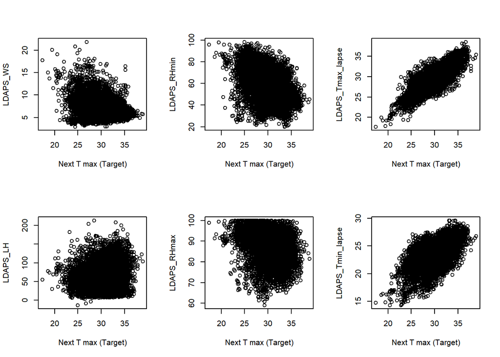

```r
layout(matrix(1:6,2,3))
 plot(data$Next_Tmax,data$LDAPS_WS , ylab="LDAPS_WS", xlab="Next T max (Target)")
 plot(data$Next_Tmax,data$LDAPS_LH , ylab="LDAPS_LH", xlab="Next T max (Target)")
 plot(data$Next_Tmax,data$LDAPS_RHmin , ylab="LDAPS_RHmin", xlab="Next T max (Target)")
 plot(data$Next_Tmax,data$LDAPS_RHmax , ylab="LDAPS_RHmax", xlab="Next T max (Target)")
 plot(data$Next_Tmax,data$LDAPS_Tmax_lapse , ylab="LDAPS_Tmax_lapse", xlab="Next T max (Target)")
 plot(data$Next_Tmax,data$LDAPS_Tmin_lapse , ylab="LDAPS_Tmin_lapse", xlab="Next T max (Target)")
```

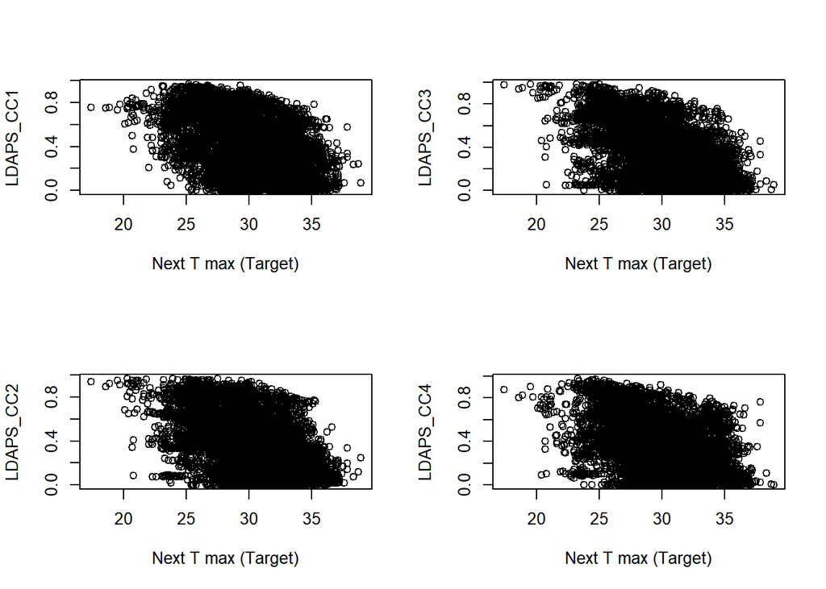

```r
layout(matrix(1:4,2,2))
 plot(data$Next_Tmax,data$LDAPS_CC1 , ylab="LDAPS_CC1", xlab="Next T max (Target)")
 plot(data$Next_Tmax,data$LDAPS_CC2 , ylab="LDAPS_CC2", xlab="Next T max (Target)")
 plot(data$Next_Tmax,data$LDAPS_CC3 , ylab="LDAPS_CC3", xlab="Next T max (Target)")
 plot(data$Next_Tmax,data$LDAPS_CC4 , ylab="LDAPS_CC4", xlab="Next T max (Target)")
```

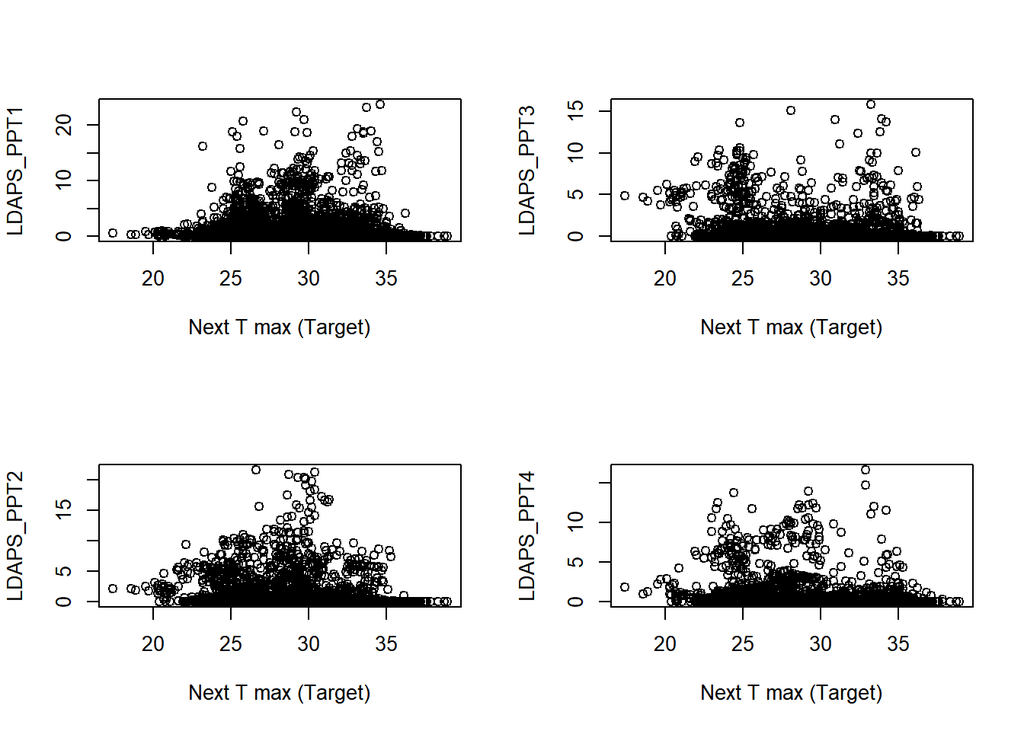

```r
layout(matrix(1:4,2,2))
 plot(data$Next_Tmax,data$LDAPS_PPT1 , ylab="LDAPS_PPT1", xlab="Next T max (Target)")
 plot(data$Next_Tmax,data$LDAPS_PPT2 , ylab="LDAPS_PPT2", xlab="Next T max (Target)")
 plot(data$Next_Tmax,data$LDAPS_PPT3 , ylab="LDAPS_PPT3", xlab="Next T max (Target)")
 plot(data$Next_Tmax,data$LDAPS_PPT4 , ylab="LDAPS_PPT4", xlab="Next T max (Target)")
```

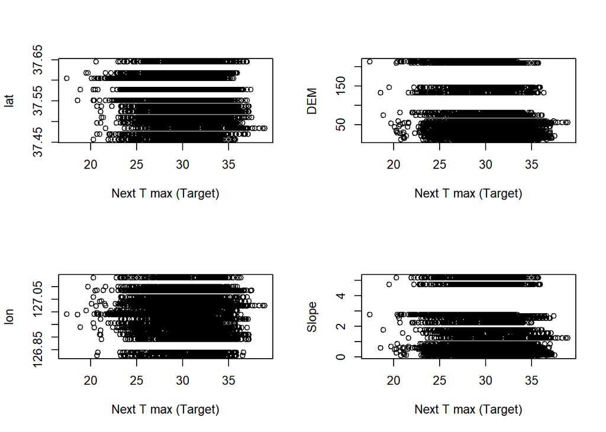

```r
 layout(matrix(1:4,2,2))
 plot(data$Next_Tmax,data$lat , ylab="lat", xlab="Next T max (Target)")
 plot(data$Next_Tmax,data$lon , ylab="lon", xlab="Next T max (Target)")
 plot(data$Next_Tmax,data$DEM , ylab="DEM", xlab="Next T max (Target)")
 plot(data$Next_Tmax,data$Slope , ylab="Slope", xlab="Next T max (Target)")
```

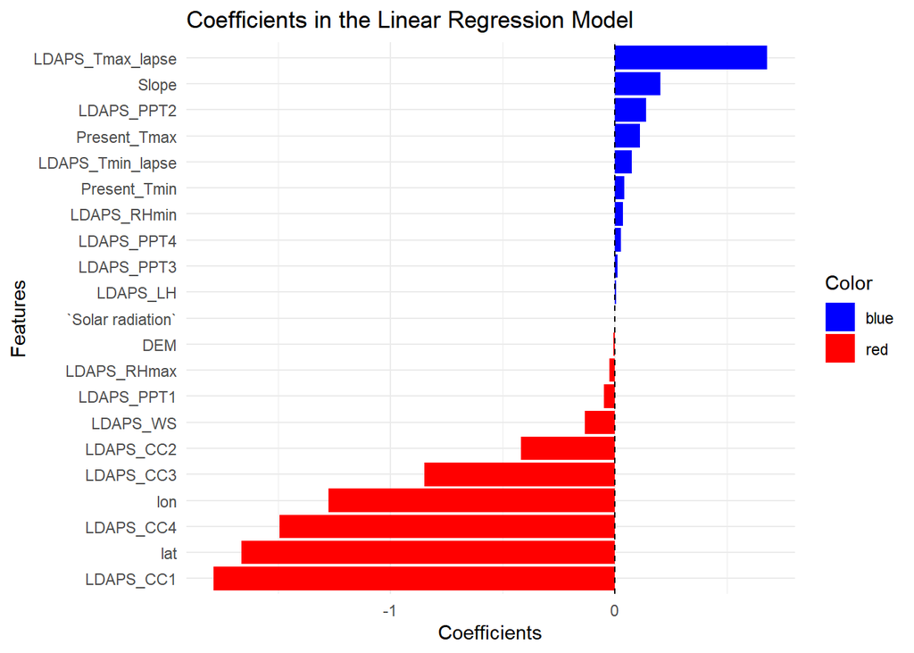

```r
coefficients <- coef(model)[-1]  # Exclude the intercept

coefficients_df <- data.frame(Feature = names(coefficients), Coefficient = coefficients)
coefficients_df$Color <- ifelse(coefficients_df$Coefficient > 0, "blue", "red")

library(ggplot2)
ggplot(coefficients_df, aes(x = reorder(Feature, Coefficient), y = Coefficient, fill = Color)) +
  geom_bar(stat = "identity") +
  coord_flip() +
  theme_minimal() +
  labs(x = "Features", y = "Coefficients", title = "Coefficients in the Linear Regression Model") +
  geom_hline(yintercept = 0, linetype = "dashed", color = "black") +
  scale_fill_manual(values = c("blue", "red"))
```

```r
# Residuals Plot
residuals <- valid_data$Next_Tmax - predictions

plot(predictions, residuals,
     xlab = "Predicted Values",
     ylab = "Residuals",
     main = "Residuals vs Predicted",
     pch = 19,
     col = "black")
abline(h = 0, col = "red", lwd = 2)
```

[output not shown]

Improvements:

### **Model 1**

```r
summary(model)$coefficients[, "Pr(>|t|)"]
```

```
##       (Intercept)      Present_Tmax      Present_Tmin       LDAPS_RHmin
##      6.060376e-11      9.644519e-21      7.675173e-03      8.812238e-25
##       LDAPS_RHmax  LDAPS_Tmax_lapse  LDAPS_Tmin_lapse          LDAPS_WS
##      4.527696e-08     2.250477e-231      1.764642e-03      9.290196e-36
##          LDAPS_LH         LDAPS_CC1         LDAPS_CC2         LDAPS_CC3
##      3.173148e-27      3.062570e-31      2.677528e-02      7.754436e-06
##         LDAPS_CC4        LDAPS_PPT1        LDAPS_PPT2        LDAPS_PPT3
##      7.492563e-24      6.134319e-05      2.698886e-24      5.557203e-01
##        LDAPS_PPT4               lat               lon               DEM
##      2.598408e-01      2.266374e-04      6.829667e-06      1.716810e-12
##             Slope `Solar radiation`
##      2.223459e-15      1.353044e-02
```

```r
non_significant_vars <- summary(model)$coefficients[, "Pr(>|t|)"] > 0.05
names(non_significant_vars[non_significant_vars])
```

```
## [1] "LDAPS_PPT3" "LDAPS_PPT4"
```

```r
# Remove the non-significant columns and Next_Tmin from the dataset
data$Present_Tmin <- NULL
data$LDAPS_PPT3 <- NULL
data$DEM <- NULL
data$Next_Tmin <- NULL

train_df1 <- subset(train_data, select = -c(Next_Tmin, Date, lon, lat, Slope, DEM, LDAPS_PPT3, LDAPS_PPT4))
valid_df1 <- subset(valid_data, select = -c(Next_Tmax, Next_Tmin, Date, lon, lat, Slope, DEM, LDAPS_PPT3, LDAPS_PPT4))

model1 <- lm(Next_Tmax ~ ., data = train_df1)

summary(model1)
```

```
##
## Call:
## lm(formula = Next_Tmax ~ ., data = train_df1)
##
## Residuals:
##     Min      1Q  Median      3Q     Max
## -5.5277 -0.8230  0.0042  0.8172  5.2315
##
## Coefficients:
##                     Estimate Std. Error t value Pr(>|t|)
## (Intercept)        5.036e+00  5.784e-01   8.708  < 2e-16 ***
## station2           8.512e-01  1.472e-01   5.782 7.86e-09 ***
## station3           7.122e-01  1.642e-01   4.338 1.47e-05 ***
## station4           1.704e+00  1.499e-01  11.363  < 2e-16 ***
## station5           9.943e-01  1.495e-01   6.652 3.23e-11 ***
## station6           1.171e+00  1.537e-01   7.622 3.02e-14 ***
## station7           1.125e+00  1.536e-01   7.324 2.83e-13 ***
## station8           1.219e+00  1.516e-01   8.042 1.12e-15 ***
## station9           1.656e+00  1.463e-01  11.322  < 2e-16 ***
## station10          1.460e+00  1.448e-01  10.084  < 2e-16 ***
## station11          1.192e+00  1.524e-01   7.819 6.58e-15 ***
## station12          1.260e+00  1.552e-01   8.113 6.30e-16 ***
## station13          1.109e+00  1.590e-01   6.972 3.58e-12 ***
## station14          1.195e+00  1.624e-01   7.361 2.16e-13 ***
## station15          9.804e-01  1.562e-01   6.277 3.77e-10 ***
## station16          6.100e-01  1.447e-01   4.215 2.55e-05 ***
## station17          8.210e-01  1.500e-01   5.475 4.62e-08 ***
## station18          2.368e+00  1.504e-01  15.741  < 2e-16 ***
## station19          1.121e+00  1.508e-01   7.431 1.28e-13 ***
## station20          2.240e+00  1.469e-01  15.244  < 2e-16 ***
## station21          4.741e-01  1.633e-01   2.904 0.003703 **
## station22          1.234e+00  1.491e-01   8.274  < 2e-16 ***
## station23          1.832e+00  1.494e-01  12.264  < 2e-16 ***
## station24          1.411e+00  1.543e-01   9.146  < 2e-16 ***
## station25          1.322e+00  1.627e-01   8.121 5.90e-16 ***
## Present_Tmax       7.358e-02  1.183e-02   6.222 5.37e-10 ***
## Present_Tmin      -3.623e-03  1.605e-02  -0.226 0.821469
## LDAPS_RHmin        3.110e-02  3.672e-03   8.470  < 2e-16 ***
## LDAPS_RHmax       -2.499e-02  4.143e-03  -6.032 1.75e-09 ***
## LDAPS_Tmax_lapse   6.777e-01  1.892e-02  35.819  < 2e-16 ***
## LDAPS_Tmin_lapse   1.483e-01  2.384e-02   6.219 5.46e-10 ***
## LDAPS_WS          -1.236e-01  1.067e-02 -11.577  < 2e-16 ***
## LDAPS_LH           7.268e-03  1.209e-03   6.010 2.01e-09 ***
## LDAPS_CC1         -1.847e+00  1.488e-01 -12.408  < 2e-16 ***
## LDAPS_CC2         -3.618e-01  1.800e-01  -2.010 0.044468 *
## LDAPS_CC3         -6.629e-01  1.800e-01  -3.684 0.000232 ***
## LDAPS_CC4         -1.476e+00  1.368e-01 -10.787  < 2e-16 ***
## LDAPS_PPT1        -3.985e-02  1.134e-02  -3.515 0.000445 ***
## LDAPS_PPT2         1.499e-01  1.302e-02  11.520  < 2e-16 ***
## `Solar radiation`  1.033e-04  5.303e-05   1.947 0.051592 .
## ---
## Signif. codes:  0 '***' 0.001 '**' 0.01 '*' 0.05 '.' 0.1 ' ' 1
##
## Residual standard error: 1.348 on 4513 degrees of freedom
## Multiple R-squared:  0.7613, Adjusted R-squared:  0.7592
## F-statistic: 369.1 on 39 and 4513 DF,  p-value: < 2.2e-16
```

```r
predictions1 <- predict(model1, newdata = valid_df1)

# Calculate new RMSE
rmse1 <- sqrt(mean((valid_data$Next_Tmax - predictions1)^2))
rmse1
```

```
## [1] 1.465021
```

```r
anova(model1, model)
```

|  | Res.Df | RSS | Df | Sum of Sq | F | Pr(>F) |
| --- | --- | --- | --- | --- | --- | --- |
| 1 | 4513 | 8205.255 | NA | NA | NA | NA |
| 2 | 4531 | 8984.234 | -18 | -778.9792 | 23.80272 | 7.386599e-76 |

```r
train_df1
```

[output not shown]

[output cut: 4543 more lines]

### **Model 2**

```r
train_df2 <- within(train_df1, {
  Night_Cloud_Cover = (LDAPS_CC1 + LDAPS_CC4) / 2
  Day_Cloud_Cover = (LDAPS_CC2 + LDAPS_CC3) / 2
  Precipitation = (LDAPS_PPT1 + LDAPS_PPT2) / 2

  # Remove the original columns
  LDAPS_CC1 = NULL
  LDAPS_CC2 = NULL
  LDAPS_CC3 = NULL
  LDAPS_CC4 = NULL
  LDAPS_PPT1 = NULL
  LDAPS_PPT2 = NULL
})

head(train_df2)
```

| station | Present_Tmax | Present_Tmin | LDAPS_RHmin | LDAPS_RHmax | LDAPS_Tmax_lapse | LDAPS_Tmin_lapse | LDAPS_WS | LDAPS_LH | Solar radiation | Next_Tmax | Precipitation | Day_Cloud_Cover | Night_Cloud_Cover |
| --- | --- | --- | --- | --- | --- | --- | --- | --- | --- | --- | --- | --- | --- |
| 1 | 28.7 | 21.4 | 58.25569 | 91.11636 | 28.07410 | 23.00694 | 6.818887 | 69.45181 | 5992.896 | 29.1 | 0 | 0.1827963 | 0.1824378 |
| 2 | 31.9 | 21.6 | 52.26340 | 90.60472 | 29.85069 | 24.03501 | 5.691890 | 51.93745 | 5869.312 | 30.5 | 0 | 0.2056077 | 0.1766177 |
| 3 | 31.6 | 23.3 | 48.69048 | 83.97359 | 30.09129 | 24.56563 | 6.138224 | 20.57305 | 5863.556 | 31.1 | 0 | 0.2307805 | 0.1757345 |
| 4 | 32.0 | 23.4 | 58.23979 | 96.48369 | 29.70463 | 23.32618 | 5.650050 | 65.72714 | 5856.965 | 31.7 | 0 | 0.1935799 | 0.1753104 |
| 5 | 31.4 | 21.9 | 56.17410 | 90.15513 | 29.11393 | 23.48648 | 5.735004 | 107.96554 | 5859.552 | 31.2 | 0 | 0.2144439 | 0.1607139 |
| 6 | 31.9 | 23.5 | 52.43713 | 85.30725 | 29.21934 | 23.82261 | 6.182295 | 50.23139 | 5873.781 | 31.5 | 0 | 0.2568295 | 0.1658208 |

```r
valid_df2 <- within(valid_df1, {
  Night_Cloud_Cover = (LDAPS_CC1 + LDAPS_CC4) / 2
  Day_Cloud_Cover = (LDAPS_CC2 + LDAPS_CC3) / 2
  Precipitation = LDAPS_PPT1 + LDAPS_PPT2 / 2

  # Remove the original columns
  LDAPS_CC1 = NULL
  LDAPS_CC2 = NULL
  LDAPS_CC3 = NULL
  LDAPS_CC4 = NULL
  LDAPS_PPT1 = NULL
  LDAPS_PPT2 = NULL
})
head(valid_df2)
```

| station | Present_Tmax | Present_Tmin | LDAPS_RHmin | LDAPS_RHmax | LDAPS_Tmax_lapse | LDAPS_Tmin_lapse | LDAPS_WS | LDAPS_LH | Solar radiation | Precipitation | Day_Cloud_Cover | Night_Cloud_Cover |
| --- | --- | --- | --- | --- | --- | --- | --- | --- | --- | --- | --- | --- |
| 14 | 30.6 | 19.8 | 33.84072 | 76.54623 | 30.60283 | 22.38152 | 6.054576 | 14.19125 | 4485.438 | 0 | 0.010994401 | 0.03198070 |
| 15 | 30.4 | 19.9 | 35.77363 | 77.67426 | 30.33172 | 22.35891 | 6.143442 | 29.16685 | 4509.859 | 0 | 0.009937652 | 0.03801072 |
| 16 | 28.8 | 18.0 | 37.36451 | 90.00015 | 29.39705 | 20.33345 | 5.807248 | 84.46328 | 4446.866 | 0 | 0.016621327 | 0.01592281 |
| 17 | 28.9 | 16.5 | 39.76587 | 94.22329 | 29.92639 | 18.99953 | 4.851530 | 107.95771 | 4500.299 | 0 | 0.013031157 | 0.02408047 |
| 18 | 30.6 | 19.9 | 36.43734 | 90.25284 | 29.79174 | 20.23983 | 5.735610 | 86.57673 | 4475.679 | 0 | 0.024382325 | 0.01949601 |
| 19 | 30.7 | 19.4 | 35.47412 | 79.58223 | 29.93316 | 21.69690 | 5.982579 | 40.68008 | 4535.020 | 0 | 0.009026008 | 0.04154792 |

```r
model2 <- lm(Next_Tmax ~ ., data = train_df2)

predictions2 <- predict(model2, newdata = valid_df2)

rmse <- sqrt(mean((valid_data$Next_Tmax - predictions2)^2))

print(rmse)
```

```
## [1] 1.431952
```

```r
summary(model2)
```

```
##
## Call:
## lm(formula = Next_Tmax ~ ., data = train_df2)
##
## Residuals:
##     Min      1Q  Median      3Q     Max
## -5.4626 -0.8074  0.0237  0.8218  5.2902
##
## Coefficients:
##                     Estimate Std. Error t value Pr(>|t|)
## (Intercept)        5.358e+00  5.784e-01   9.264  < 2e-16 ***
## station2           8.619e-01  1.486e-01   5.800 7.08e-09 ***
## station3           7.296e-01  1.656e-01   4.407 1.07e-05 ***
## station4           1.726e+00  1.516e-01  11.387  < 2e-16 ***
## station5           1.016e+00  1.512e-01   6.718 2.07e-11 ***
## station6           1.188e+00  1.553e-01   7.654 2.37e-14 ***
## station7           1.147e+00  1.553e-01   7.384 1.82e-13 ***
## station8           1.222e+00  1.532e-01   7.974 1.93e-15 ***
## station9           1.667e+00  1.478e-01  11.275  < 2e-16 ***
## station10          1.445e+00  1.464e-01   9.874  < 2e-16 ***
## station11          1.214e+00  1.540e-01   7.884 3.93e-15 ***
## station12          1.257e+00  1.567e-01   8.027 1.26e-15 ***
## station13          1.130e+00  1.605e-01   7.043 2.17e-12 ***
## station14          1.189e+00  1.638e-01   7.255 4.70e-13 ***
## station15          9.908e-01  1.577e-01   6.283 3.64e-10 ***
## station16          6.012e-01  1.464e-01   4.107 4.09e-05 ***
## station17          8.241e-01  1.516e-01   5.436 5.73e-08 ***
## station18          2.380e+00  1.520e-01  15.653  < 2e-16 ***
## station19          1.119e+00  1.523e-01   7.351 2.32e-13 ***
## station20          2.250e+00  1.486e-01  15.139  < 2e-16 ***
## station21          5.014e-01  1.648e-01   3.043  0.00236 **
## station22          1.259e+00  1.508e-01   8.347  < 2e-16 ***
## station23          1.849e+00  1.510e-01  12.246  < 2e-16 ***
## station24          1.426e+00  1.559e-01   9.145  < 2e-16 ***
## station25          1.332e+00  1.642e-01   8.111 6.43e-16 ***
## Present_Tmax       8.439e-02  1.151e-02   7.332 2.67e-13 ***
## Present_Tmin      -2.217e-02  1.603e-02  -1.383  0.16685
## LDAPS_RHmin        3.409e-02  3.654e-03   9.329  < 2e-16 ***
## LDAPS_RHmax       -2.934e-02  4.046e-03  -7.251 4.83e-13 ***
## LDAPS_Tmax_lapse   6.835e-01  1.888e-02  36.201  < 2e-16 ***
## LDAPS_Tmin_lapse   1.367e-01  2.346e-02   5.828 6.02e-09 ***
## LDAPS_WS          -1.224e-01  1.079e-02 -11.347  < 2e-16 ***
## LDAPS_LH           7.178e-03  1.214e-03   5.912 3.62e-09 ***
## `Solar radiation`  1.086e-04  5.299e-05   2.050  0.04044 *
## Precipitation      8.416e-02  1.453e-02   5.793 7.39e-09 ***
## Day_Cloud_Cover   -5.374e-01  2.232e-01  -2.408  0.01608 *
## Night_Cloud_Cover -3.656e+00  2.038e-01 -17.935  < 2e-16 ***
## ---
## Signif. codes:  0 '***' 0.001 '**' 0.01 '*' 0.05 '.' 0.1 ' ' 1
##
## Residual standard error: 1.365 on 4516 degrees of freedom
## Multiple R-squared:  0.7554, Adjusted R-squared:  0.7534
## F-statistic: 387.4 on 36 and 4516 DF,  p-value: < 2.2e-16
```

```r
summary(model2)$coefficients[, "Pr(>|t|)"]
```

```
##       (Intercept)          station2          station3          station4
##      2.966230e-20      7.080116e-09      1.072493e-05      1.230780e-29
##          station5          station6          station7          station8
##      2.070290e-11      2.374584e-14      1.823000e-13      1.927438e-15
##          station9         station10         station11         station12
##      4.242386e-29      9.207510e-23      3.934371e-15      1.261330e-15
##         station13         station14         station15         station16
##      2.168611e-12      4.698410e-13      3.638506e-10      4.087312e-05
##         station17         station18         station19         station20
##      5.728521e-08      8.063978e-54      2.322741e-13      1.523495e-50
##         station21         station22         station23         station24
##      2.357054e-03      9.193862e-17      6.063895e-34      8.825244e-20
##         station25      Present_Tmax      Present_Tmin       LDAPS_RHmin
##      6.429237e-16      2.674240e-13      1.668512e-01      1.631955e-20
##       LDAPS_RHmax  LDAPS_Tmax_lapse  LDAPS_Tmin_lapse          LDAPS_WS
##      4.826490e-13     3.494525e-252      6.015211e-09      1.912460e-29
##          LDAPS_LH `Solar radiation`     Precipitation   Day_Cloud_Cover
##      3.624385e-09      4.044390e-02      7.386235e-09      1.608306e-02
## Night_Cloud_Cover
##      1.531597e-69
```

```r
non_significant_vars <- summary(model2)$coefficients[, "Pr(>|t|)"] > 0.05
names(non_significant_vars[non_significant_vars])
```

```
## [1] "Present_Tmin"
```

```r
anova(model2, model1)
```

|  | Res.Df | RSS | Df | Sum of Sq | F | Pr(>F) |
| --- | --- | --- | --- | --- | --- | --- |
| 1 | 4516 | 8408.685 | NA | NA | NA | NA |
| 2 | 4513 | 8205.255 | 3 | 203.4297 | 37.29635 | 8.410455e-24 |

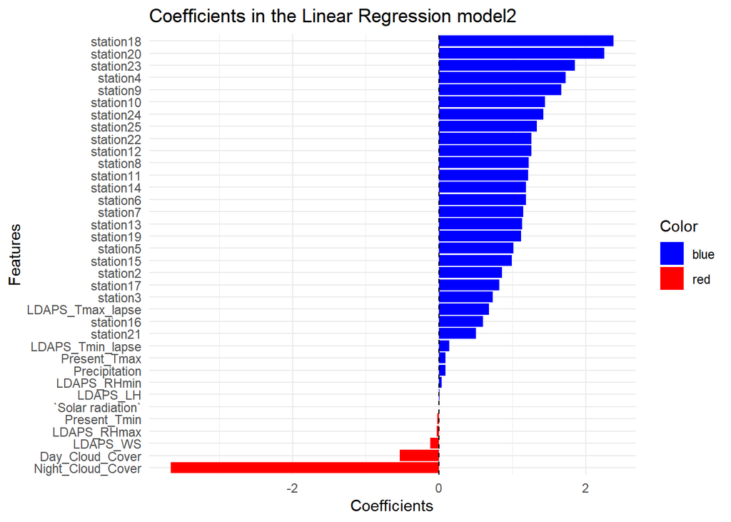

```r
coefficients <- coef(model2)[-1]

coefficients_df <- data.frame(Feature = names(coefficients), Coefficient = coefficients)
coefficients_df$Color <- ifelse(coefficients_df$Coefficient > 0, "blue", "red")

ggplot(coefficients_df, aes(x = reorder(Feature, Coefficient), y = Coefficient, fill = Color)) +
  geom_bar(stat = "identity") +
  coord_flip() +
  theme_minimal() +
  labs(x = "Features", y = "Coefficients", title = "Coefficients in the Linear Regression model2") +
  geom_hline(yintercept = 0, linetype = "dashed", color = "black") +
  scale_fill_manual(values = c("blue", "red"))
```

```r
residuals <- valid_data$Next_Tmax - predictions

plot(predictions, residuals,
     xlab = "Predicted Values",
     ylab = "Residuals",
     main = "Residuals vs Predicted",
     pch = 19,
     col = "black")
abline(h = 0, col = "red", lwd = 2)
```

[output not shown]

### **Model 3**

```r
train_df3 = train_df2
valid_df3 = valid_df2
```

```r
train_df3$Present_Tmin <- NULL
valid_df3$Present_Tmin <- NULL

model3 <- lm(Next_Tmax ~ ., data = train_df3)

predictions3 <- predict(model3, newdata = valid_df3)

rmse <- sqrt(mean((valid_data$Next_Tmax - predictions3)^2))

print(rmse)
```

```
## [1] 1.427989
```

```r
summary(model3)$coefficients[, "Pr(>|t|)"]
```

```
##       (Intercept)          station2          station3          station4
##      3.581151e-20      8.594860e-09      2.160638e-05      2.697849e-29
##          station5          station6          station7          station8
##      4.033351e-11      6.193104e-14      4.504811e-13      5.049505e-15
##          station9         station10         station11         station12
##      1.076020e-28      1.920073e-22      1.031099e-14      2.148432e-15
##         station13         station14         station15         station16
##      5.713142e-12      1.163389e-12      7.797537e-10      4.532234e-05
##         station17         station18         station19         station20
##      5.767960e-08      7.621044e-54      4.573071e-13      2.818758e-50
##         station21         station22         station23         station24
##      4.452705e-03      2.360320e-16      1.155000e-33      2.068781e-19
##         station25      Present_Tmax       LDAPS_RHmin       LDAPS_RHmax
##      1.676716e-15      6.580759e-13      2.214436e-20      3.348754e-14
##  LDAPS_Tmax_lapse  LDAPS_Tmin_lapse          LDAPS_WS          LDAPS_LH
##     8.432877e-253      8.531739e-09      1.839901e-30      6.035723e-09
## `Solar radiation`     Precipitation   Day_Cloud_Cover Night_Cloud_Cover
##      2.627857e-02      1.810371e-08      2.034394e-02      1.499942e-70
```

```r
non_significant_vars <- summary(model3)$coefficients[, "Pr(>|t|)"] > 0.05
names(non_significant_vars[non_significant_vars])
```

```
## character(0)
```

```r
anova(model3, model)
```

|  | Res.Df | RSS | Df | Sum of Sq | F | Pr(>F) |
| --- | --- | --- | --- | --- | --- | --- |
| 1 | 4517 | 8412.244 | NA | NA | NA | NA |
| 2 | 4531 | 8984.234 | -14 | -571.9901 | 21.93809 | 3.861121e-55 |

[figure not shown]

```r
coefficients <- coef(model3)[-1]  # Exclude the intercept

coefficients_df <- data.frame(Feature = names(coefficients), Coefficient = coefficients)
coefficients_df$Color <- ifelse(coefficients_df$Coefficient > 0, "blue", "red")

ggplot(coefficients_df, aes(x = reorder(Feature, Coefficient), y = Coefficient, fill = Color)) +
  geom_bar(stat = "identity") +
  coord_flip() +
  theme_minimal() +
  labs(x = "Features", y = "Coefficients", title = "Coefficients in the Linear Regression model2") +
  geom_hline(yintercept = 0, linetype = "dashed", color = "black") +
  scale_fill_manual(values = c("blue", "red"))
```

```r
# Residuals Plot
residuals <- valid_data$Next_Tmax - predictions

plot(predictions, residuals,
     xlab = "Predicted Values",
     ylab = "Residuals",
     main = "Residuals vs Predicted",
     pch = 19,
     col = "black")
abline(h = 0, col = "red", lwd = 2)
```

[output not shown]

```r
shapiro.test(model3$residuals)
```

```
##
##  Shapiro-Wilk normality test
##
## data:  model3$residuals
## W = 0.98899, p-value < 2.2e-16
```

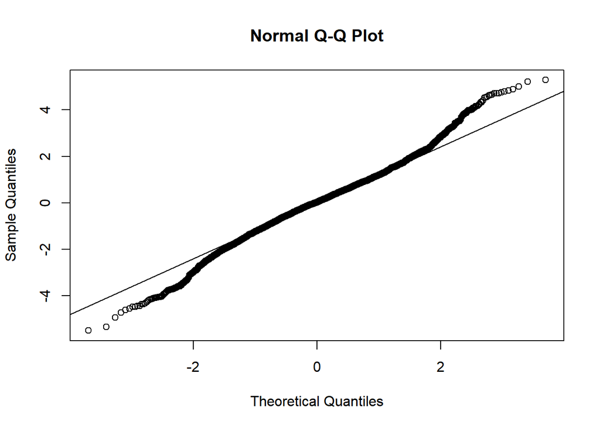

```r
{
 qqnorm(model3$residuals)
 qqline(model3$residuals)
}
```

```r
test_data_subset <- test_data[, predictors]
test_predictions <- predict(model, newdata = test_data_subset)
test_rmse1 <- sqrt(mean((test_data$Next_Tmax - test_predictions)^2))
test_rmse1
```

```
## [1] 1.647331
```

```r
test_df2 <- within(test_data, {
  Night_Cloud_Cover = (LDAPS_CC1 + LDAPS_CC4) / 2
  Day_Cloud_Cover = (LDAPS_CC2 + LDAPS_CC3) / 2
  Precipitation = (LDAPS_PPT1 + LDAPS_PPT2) / 2

  LDAPS_CC1 = NULL
  LDAPS_CC2 = NULL
  LDAPS_CC3 = NULL
  LDAPS_CC4 = NULL
  LDAPS_PPT1 = NULL
  LDAPS_PPT2 = NULL
  Next_Tmin = NULL
  Date = NULL
  lon = NULL
  lat = NULL
  Slope = NULL
  DEM = NULL
  LDAPS_PPT3 = NULL
  LDAPS_PPT4 = NULL
})

test_predictions2 <- predict(model3, newdata = test_df2)
test_rmse2 <- sqrt(mean((test_data$Next_Tmax - test_predictions2)^2))
test_rmse2
```

```
## [1] 1.591924
```